# Motivation

## LM: Visualize Interaction Effects

- For LMs we have to include interactions explicitely in order to visualize their effect.
- For ML algorithms, we don’t because they usually automatically recognize interactions.

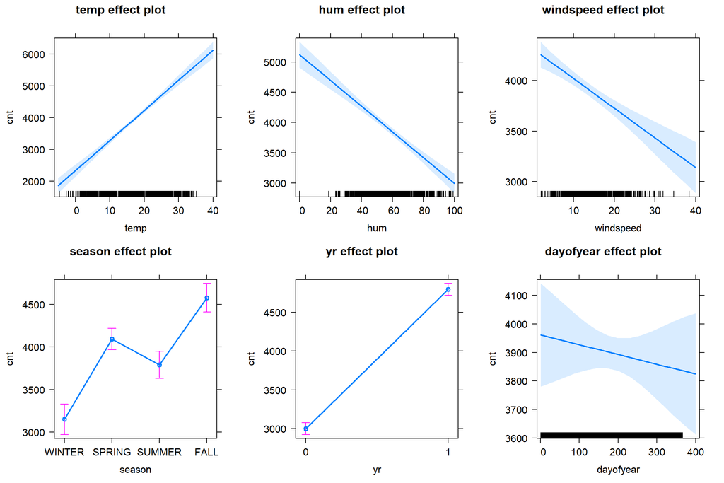

```r
bike = readRDS("bike.Rds")

library(effects)
# Marginal effects for lm
mod = lm(cnt ~ temp + hum + windspeed + season + yr + dayofyear, data = bike)
plot(allEffects(mod))
```

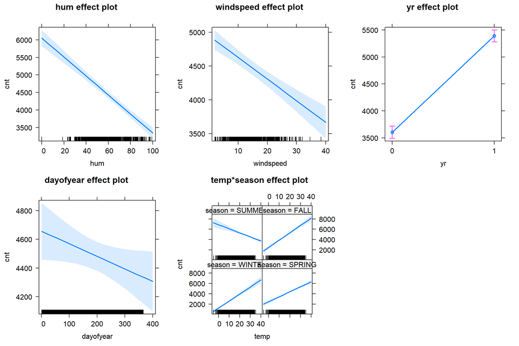

```r
# Marginal effects for lm with interaction between categorical and numeric feature
mod2 = lm(cnt ~ temp + hum + windspeed + season + yr + dayofyear + temp*season, data = bike)
plot(allEffects(mod2))
```

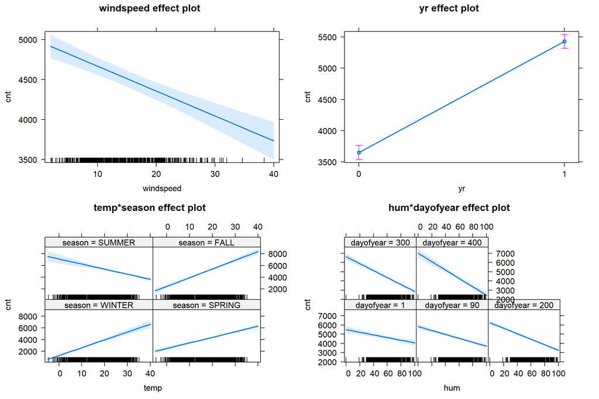

```r
# Marginal effects for lm with interaction between categorical and numeric and 2 numeric features
mod3 = lm(cnt ~ temp + hum + windspeed + season + yr + dayofyear + temp*season + dayofyear*hum,
  data = bike)
plot(allEffects(mod3))
```

- **AIM:**
  - We want to produce similar visualizations for arbitrary ML models.
  - Additionally, we are looking for an procedure that automatically finds interesting interactions in a data-driven way (e.g. using the information from ICE curves).

## ML: Visualize Interaction Effects

- For ML models, we can visualize global main effects (PDP) and local effects (ICE).
- But: We do not know which interactions were found by the ML model and which ones are interesting to look at.

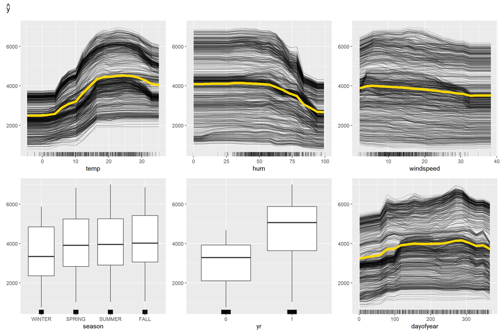

```r
library(iml)
library(ranger)
rf = ranger(cnt ~ temp + hum + windspeed + season + yr + dayofyear, data = bike)
mod = Predictor$new(rf, data = bike,
  predict.function = function(model, newdata) predict(model, newdata)$predictions)
feature = c("temp", "hum", "windspeed", "season", "yr", "dayofyear")

eff = FeatureEffects$new(mod, feature = feature, method = "pdp+ice", grid.size = 20)
eff$plot()
```

We can visualize interactions in a 2-dimensional PDP plot:

1. interaction between numeric and categorical features

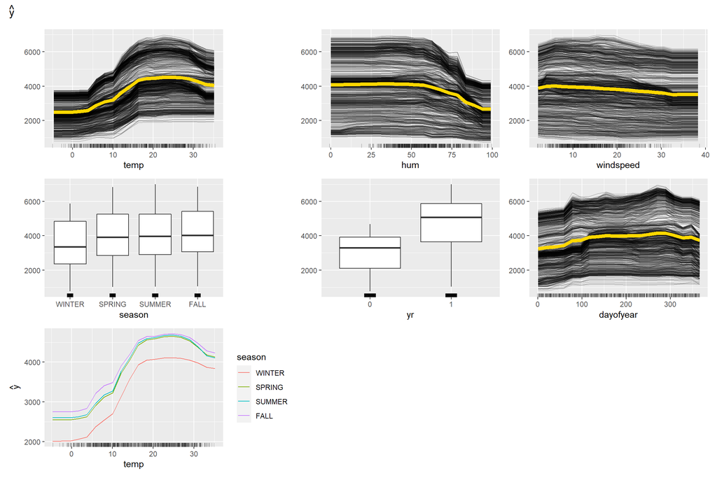

```r
eff2 = FeatureEffect$new(mod, feature = c("temp", "season"), method = "pdp", grid.size = 20)
eff$plot() + eff2$plot()
```

2. interaction between numeric and categorical, and between 2 numeric features

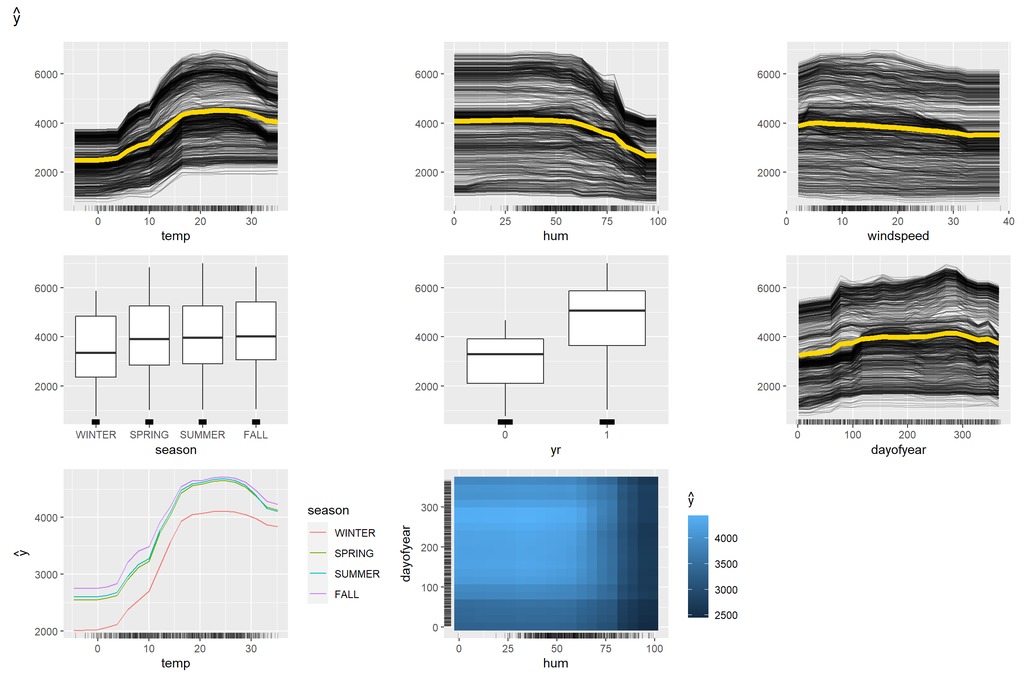

```r
eff3 = FeatureEffect$new(mod, feature = c("hum", "dayofyear"), method = "pdp", grid.size = 20)
eff$plot() + eff2$plot() + eff3$plot()
```

## Issues

- 2d PDPs are computationally expensive but show interaction effects as a heatmap.
- **Idea:** Instead, we use the information from ICE curves to find interactions and produce visualizations for the most interesting interactions as follows:
  1. Compute ICE curves for feature of interest
  2. Check if the ICE curves can be splitted by another feature (-> potential interaction)
  3. The feature that most likely interacts with our feature of interest has lowest objective.
  4. We can even get a ranking (sorted according to the objective) of which other feature might also interact with our feature of interest.